# Characterization Package Specification

### 2.3.5 Intermediary Plots

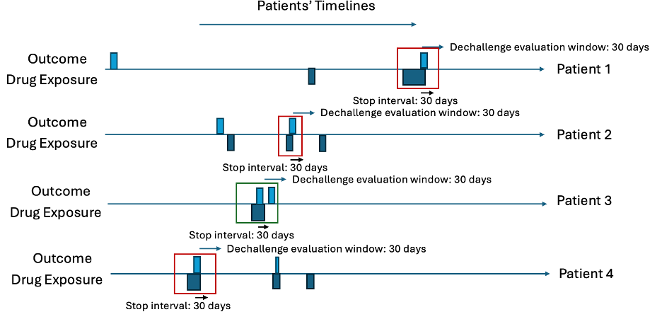

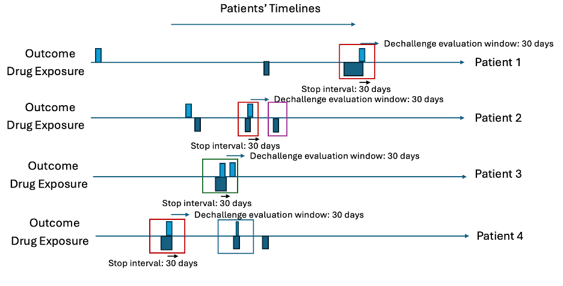

### 2.3.6 Summary

We would then summarize the results by saying there were 4 dechallenges, 3 of which were a success and 1 of which was a fail. 2 patients had rechallenges with 1 being a fail and 1 being a success, see Table 8 as the example output for one target and outcome.

Table: Dehcallenge-rechallenge output.

| dechallengeAttempts | dechallengeSuccess | dechallengeFailure | rechallengeAttempts | rechallengeSuccess | rechallangeFailure |
| --- | --- | --- | --- | --- | --- |
| 4 | 3 | 1 | 2 | 1 | 1 |

**Note:** The way an outcome and exposure phenotype are designed can make it impossible or unlikely to see a dechallenge fail. For example, if an outcome is designed with a 365 day washout window, then it means there cannot be another outcome occurring within 365 days of another outcome. As a dechallange failure is the outcome occurring within dechallenge evaluation window days after the exposure ends (and the exposure must end within stop interval days of the outcome to be a dechallenge), then using the defaults for these values means a dechallenge failure requires an outcome to be possible within 60 days of the dechallenge outcome, which is impossible with a 365 washout window.

# 3 Aggregate Covariates

## 3.1 Inputs

A vector of targetIds plus the minimum prior observation required for the target cohorts and specifying which features to extract (covariateSettings).

## 3.2 Outputs

For each target cohort restricted to only the patients with minimum prior observation at index and first occurrence the mean value for each feature of interest is extracted into a data.frame.

## 3.3 Worked Example

The aggregate covariates calculates the mean value of a feature within a cohort of patients. In this analysis we restrict to first occurrence in the cohort with a minimum prior observation in days specified by the user (default 365 days). This restriction is implemented as otherwise a patient could contribute multiple times to the mean value and this makes interpretation difficult.

### 3.3.1 Example Inputs

Here we consider the inputs are:

```r
minPriorObservation <- 365
covariateSettings <- FeatureExtraction::createCovariateSettings(
  useDemographicsAge = T,
  useDemographicsGender = T,
  useConditionOccurrenceAnyTimePrior = T, includedCovariateConceptIds = c(201820)
  )
```

### 3.3.2 Example Data

Let’s assumed we have two two cohorts (id 1 and 2) the first cohort contains five patients who have >365 days prior observation at index and the second contains three patients who have >365 days prior observation at index.

Table: Example patient level feature data.

| patientId | cohortId | feature | value |
| --- | --- | --- | --- |
| 1 | 1 | age | 50 |
| 1 | 1 | sex | Male |
| 1 | 1 | diabetes | Yes |
| 2 | 1 | age | 18 |
| 2 | 1 | sex | Female |
| 2 | 1 | diabetes | No |
| 3 | 1 | age | 22 |
| 3 | 1 | sex | Male |
| 3 | 1 | diabetes | No |
| 4 | 1 | age | 40 |
| 4 | 1 | sex | Male |
| 4 | 1 | diabetes | No |
| 5 | 1 | age | 70 |
| 5 | 1 | sex | Female |
| 5 | 1 | diabetes | Yes |
| 1 | 2 | age | 24 |
| 1 | 2 | sex | Female |
| 1 | 2 | diabetes | No |
| 2 | 2 | age | 35 |
| 2 | 2 | sex | Female |
| 2 | 2 | diabetes | No |
| 3 | 2 | age | 31 |
| 3 | 2 | sex | Female |
| 3 | 2 | diabetes | No |

### 3.3.3 Results

We calculate the mean values for each feature per cohort:

Table: Example aggregate features for two example cohorts.

| cohortId | feature | mean |
| --- | --- | --- |
| 1 | Age | 40.0 |
| 1 | Sex: Male | 0.6 |
| 1 | Diabetes: Yes | 0.4 |
| 2 | Age | 30.0 |
| 2 | Sex: Male | 0.0 |
| 2 | Diabetes: Yes | 0.0 |

The database and cohort comparison implements the aggregate covariate analysis for all target and outcome ids fed into characterization across all OMOP CDM databases available and then lets users compare the mean values of the features between databases for the same cohort or across different cohorts within the same database. The standardized mean different is calculated between two cohorts when possible, this is calculated per feature as: abs(mean value in cohort 1 - mean value in cohort 2)/((standard deviation of values in cohort 1 squared plus standard deviation of values in cohort 2 squared)/2).

# 4 Risk Factor Analysis

## 4.1 Inputs

A vector of targetIds and outcomeIds plus the minimum prior observation required for the target cohorts, the outcome washout days for the outcomes, settings for the time-at-risk and covariate settings specifying which features to extract.

## 4.2 Outputs

For each target and outcome combination we run aggregate covariate analysis for the special case of comparing patients in cohort 1 (patients in the target cohort for the first time with 365 days prior observation who go on to have the first occurrence of the outcome in washout days during some time-at-risk relative to the target cohort index) vs cohort 2 (patients in the target cohort for the first time with 365 days prior observation who do not go on to have the first occurrence of the outcome in washout days during some time-at-risk relative to the target cohort index).

## 4.3 Worked Example

Lets consider an example with a time-at-risk of target cohort start + 1 to target cohort start + 180.

### 4.3.1 Example Inputs

```r
targetId <- 1
outcomeId <- 2
minPriorObservation <- 365
outcomeWashoutDays <- 365
riskWindowStart <- 1
startAnchor <- 'cohort start'
riskWindowEnd <- 180
endAnchor <- 'cohort start'
covariateSettings <- FeatureExtraction::createCovariateSettings(
  useDemographicsAge = T,
  useDemographicsGender = T,
  useConditionOccurrenceAnyTimePrior = T, includedCovariateConceptIds = c(201820)
  )
```

### 4.3.2 Example Data

Table: Example target cohort.

| patientId | targetCohortId | cohortStartDate | cohortEndDate | observationStart |
| --- | --- | --- | --- | --- |
| 1 | 1 | 2001-01-20 | 2001-01-25 | 2000-02-01 |
| 1 | 1 | 2001-10-20 | 2001-12-05 | 2000-02-01 |
| 2 | 1 | 2005-09-10 | 2005-09-15 | 2001-02-01 |
| 3 | 1 | 2004-04-02 | 2004-05-17 | 2001-02-01 |
| 4 | 1 | 2002-03-03 | 2002-06-12 | 2001-02-01 |
| 4 | 1 | 2003-02-01 | 2003-02-30 | 2001-02-01 |
| 4 | 1 | 2003-08-04 | 2003-08-24 | 2001-02-01 |
| 5 | 1 | 2005-02-01 | 2005-10-08 | 2001-02-01 |
| 5 | 1 | 2007-04-03 | 2007-05-03 | 2001-02-01 |

Example outcome cohort.

| patientId | targetCohortId | cohortStartDate | cohortEndDate |
| --- | --- | --- | --- |
| 1 | 2 | 1999-10-03 | 1999-10-08 |
| 1 | 2 | 2001-10-30 | 2001-11-07 |
| 3 | 2 | 2004-05-16 | 2004-05-18 |
| 4 | 2 | 2002-06-03 | 2002-06-14 |
| 4 | 2 | 2003-02-20 | 2003-03-01 |
| 5 | 2 | 2006-07-21 | 2006-08-03 |
| 5 | 2 | 2008-01-01 | 2008-01-09 |

### 4.3.3 Intermedeiary Tables

First, we find the first target with 365 days prior obs. Patient 1 is removed as they are exposed for the first time with less than 365 days prior observation. Patients 4 and 5 non-first exposures are removed. This leaves:

Table: Example target cohort meeting risk factor inclusion criteria.

| patientId | targetCohortId | cohortStartDate | cohortEndDate |
| --- | --- | --- | --- |
| 2 | 1 | 2005-09-10 | 2005-09-15 |
| 3 | 1 | 2004-04-02 | 2004-05-17 |
| 4 | 1 | 2002-03-03 | 2002-06-12 |
| 5 | 1 | 2005-02-01 | 2005-10-08 |

We then find the patients in the target cohort with the outcome and no-outcome occurring during 1 day to 180 days after index:

Table: Example target cohort meeting risk factor inclusion criteria.

| patientId | targetCohortId | cohortStartDate | cohortEndDate | labels |
| --- | --- | --- | --- | --- |
| 2 | 1 | 2005-09-10 | 2005-09-15 | Non-outcome |
| 3 | 1 | 2004-04-02 | 2004-05-17 | Outcome |
| 4 | 1 | 2002-03-03 | 2002-06-12 | Outcome |
| 5 | 1 | 2005-02-01 | 2005-10-08 | Non-outcome |

**Note:** we also remove patients in the target who have the outcome during outcome washout days prior to target index. In the example, nobody had the outcome prior, so this was not observed.

If the features for these four patients are:

Table: Example patient level feature data.

| patientId | cohortId | feature | value |
| --- | --- | --- | --- |
| 2 | Non-outcome | age | 50 |
| 2 | Non-outcome | sex | Male |
| 2 | Non-outcome | diabetes | Yes |
| 3 | Outcome | age | 18 |
| 3 | Outcome | sex | Female |
| 3 | Outcome | diabetes | No |
| 4 | Outcome | age | 22 |
| 4 | Outcome | sex | Male |
| 4 | Outcome | diabetes | No |
| 5 | Non-outcome | age | 40 |
| 5 | Non-outcome | sex | Male |
| 5 | Non-outcome | diabetes | No |

### 4.3.4 Results

We calculate the mean values for each feature per non-outcome and outcome cohort:

Table: Example aggregate features for risk factor analysis.

| cohortId | feature | mean |
| --- | --- | --- |
| Outcome | Age | 20.0 |
| Outcome | Sex: Male | 0.5 |
| Outcome | Diabetes: Yes | 0.0 |
| Non-outcome | Age | 45.0 |
| Non-outcome | Sex: Male | 1.0 |
| Non-outcome | Diabetes: Yes | 0.5 |

We can then implement the standardized mean different calculated between the outcome and non-outcome cohorts, this is calculated per feature as: abs(mean value in outcome cohort - mean value in non-outcome cohort)/((standard deviation of values in outcome cohort squared plus standard deviation of values in non-outcome cohort squared)/2).

# 5 Case Series

The cases series looks at the patients in a target cohort who have the outcome during a specified time-at-risk and calculates the aggregate covariates at three different time periods: shortly before index, between target index and outcome index and shortly after outcome index.

## 5.1 Inputs

A vector of targetIds and outcomeIds plus the minimum prior observation required for the target cohorts, the outcome washout days for the outcomes, settings for the time-at-risk and covariate settings specifying which features to extract.

In addition you need to specify how long before target index to extract before index features (preTargetIndexDays) and how long after outcome index to extract after index features (postOutcomeIndexDays).

## 5.2 Outputs

For each target and outcome combination we run aggregate covariate analysis patients in the target patients (with a minimum of prior observation day before index) who have the outcome (for the first time in outcome washout days). We use three different time periods for feature extraction:

- (before) preTargetIndexDays before target index up to target index
- (during) between target index plus 1 day to outcome index
- (after) 1 day after outcome index to outcome index plus postOutcomeIndexDays

## 5.3 Worked Example

In this example we look at how often diabetes is recorded for the cases (people with the target cohort who have the outcome within 180 days of target index) in the year before target index, between target index and outcome index and the 1 year after outcome index.

### 5.3.1 Example Inputs

Here we consider the inputs are:

```r
targetId <- 1
outcomeId <- 2
minPriorObservation <- 365
outcomeWashoutDays <- 365
preTargetIndexDays <- 365
postOutcomeIndexDays <- 365
riskWindowStart <- 1
startAnchor <- 'cohort start'
riskWindowEnd <- 180
endAnchor <- 'cohort start'
covariateSettings <- FeatureExtraction::createCovariateSettings(
  useConditionOccurrenceAnyTimePrior = T, includedCovariateConceptIds = c(201820)
  )
```

### 5.3.2 Example Data

Table: Example target cohort.

| patientId | targetCohortId | cohortStartDate | cohortEndDate | observationStart |
| --- | --- | --- | --- | --- |
| 1 | 1 | 2001-01-20 | 2001-01-25 | 2000-02-01 |
| 1 | 1 | 2001-10-20 | 2001-12-05 | 2000-02-01 |
| 2 | 1 | 2005-09-10 | 2005-09-15 | 2001-02-01 |
| 3 | 1 | 2004-04-02 | 2004-05-17 | 2001-02-01 |
| 4 | 1 | 2002-03-03 | 2002-06-12 | 2001-02-01 |
| 4 | 1 | 2003-02-01 | 2003-02-30 | 2001-02-01 |
| 4 | 1 | 2003-08-04 | 2003-08-24 | 2001-02-01 |
| 5 | 1 | 2005-02-01 | 2005-10-08 | 2001-02-01 |
| 5 | 1 | 2007-04-03 | 2007-05-03 | 2001-02-01 |

| patientId | targetCohortId | cohortStartDate | cohortEndDate |
| --- | --- | --- | --- |
| 1 | 2 | 1999-10-03 | 1999-10-08 |
| 1 | 2 | 2001-10-30 | 2001-11-07 |
| 3 | 2 | 2004-05-16 | 2004-05-18 |
| 4 | 2 | 2002-06-03 | 2002-06-14 |
| 4 | 2 | 2003-02-20 | 2003-03-01 |
| 5 | 2 | 2006-07-21 | 2006-08-03 |
| 5 | 2 | 2008-01-01 | 2008-01-09 |

### 5.3.3 Intermedeiary Tables

First, we find the first target with 365 days prior obs. Patient 1 is removed as they are exposed for the first time with less than 365 days prior observation. Patients 4 and 5 non-first exposures are removed. This leaves:

Table: Example target cohort meeting risk factor inclusion criteria.

| patientId | targetCohortId | cohortStartDate | cohortEndDate |
| --- | --- | --- | --- |
| 2 | 1 | 2005-09-10 | 2005-09-15 |
| 3 | 1 | 2004-04-02 | 2004-05-17 |
| 4 | 1 | 2002-03-03 | 2002-06-12 |
| 5 | 1 | 2005-02-01 | 2005-10-08 |

We then find the patients in the target cohort with the outcome occurring during 1 day to 180 days after index:

Table: Example target cohort meeting case inclusion criteria.

| patientId | targetCohortId | cohortStartDate | cohortEndDate | labels |
| --- | --- | --- | --- | --- |
| 3 | 1 | 2004-04-02 | 2004-05-17 | Outcome |
| 4 | 1 | 2002-03-03 | 2002-06-12 | Outcome |

**Note:** we also remove patients in the target who have the outcome during outcome washout days prior to target index. In the example, nobody had the outcome prior, so this was not observed.

Now we define the before( 365 days before target index up to target index), between (target index plus 1 and outcome) and after (outcome index plus 1 to outcome index plus 365):

Table: Example cases with before/during/after dates.

| patientId | targetCohortId | targetStartDate | outcomeStartDate | beforeStartDate | beforeEndDate | duringStartDate | duringEndDate | afterStartDate | afterEndDate |
| --- | --- | --- | --- | --- | --- | --- | --- | --- | --- |
| 3 | 1 | 2004-04-02 | 2004-05-16 | 2003-04-03 | 2004-04-02 | 2004-04-03 | 2004-05-16 | 2004-05-17 | 2005-05-16 |
| 4 | 1 | 2002-03-03 | 2002-06-03 | 2001-03-03 | 2002-03-03 | 2002-03-04 | 2002-06-03 | 2002-06-04 | 2003-06-03 |

If the features for these two patients at the three time periods are:

Table: Example patient level case feature data.

| patientId | feature | timePeriod | value |
| --- | --- | --- | --- |
| 3 | diabetes | before | No |
| 3 | diabetes | during | No |
| 3 | diabetes | after | Yes |
| 4 | diabetes | before | Yes |
| 4 | diabetes | during | Yes |
| 4 | diabetes | after | Yes |

### 5.3.4 Results

Finally, we aggregate over the time periods:

Table: Example patient level case feature data.

| feature | timePeriod | value |
| --- | --- | --- |
| diabetes: Yes | before | 0.5 |
| diabetes: Yes | during | 0.5 |
| diabetes: Yes | after | 1.0 |